# Notes

# About

These are class notes and R code for Professor Ge Zhao’s STAT-464 : Applied Regression Analysis for Fall term 2021 at Portland State University.

$\newcommand{\indep}{\perp \!\!\! \perp}$

# W1-D1 : Mon. Sept. 27, 2021

- will ask around for a bigger room
- assume we have basic understanding of R

## Introduction : Chapter 1

| X | Y |
| --- | --- |
| continuous | continuous |
| categrorical : ordinal data and nominal data | categorical : ordinal data and nominal data |

- ordinal data (can be ordered) and nominal data (different types of data)”
- in regression class most of the time we are focuses on X=Y : Continuous vs Continuous
- in experimental design we are focused on Y=X : Continuous vs Categorical
- special case (in later chapters) Y=X : Ordinal vs. continuous
- later (in other classes) we may see (double line) experimental design looks at every combination of categorical vs. categorical .

### Summary / Thoughts

We are focusing on data, and relations between $X$ and $Y$.

Regressions would have continuous vs. continuous. This reminds me graphically of physics problems. How far does something go in a certain amount of time.

Experimental design would have a continuous $Y$ vs. a Categorical $X$. Graphically I think of histograms.

Some of the special cases I would need to think about.

# W1-D2 : Wed. Sept. 29, 2021

- If you cannot attend in person use zoom number in D2L link

### Simple Linear Regression Model

A model with a single regressor (predictor) x that has a relationship with a response y that is a straight line line.
$$y=\beta _{0}+\beta _{1}x+\epsilon$$

- $x$ is the data, $\beta _{0}$ is the intercept, $\beta _{1}$ is the slope, and $\epsilon$ is a random error component.
  - $\beta$ unknown constants (parameters)
  - x is independent variable (predictor or regressor) and y is dependent variable (response).
  - simple because there is only one regressor (x).
  - the slope $\beta_{1}$ is the change in the mean of the distribution of y produced by a unit change in x.
  - example might be $x_1$ = pulse rate (rest rate), and $y$ might be oxygen consumption rate (oxygen rate)
- data points don’t fall on a straight line so we can quantify the distances between each point and the best fit line
- $\epsilon$ is assumed to have an expectation or mean of 0 and an unknown variance $\sigma ^{2}$.

Why can you make the assumption that the expectation of $\epsilon$ is zero?

- The expectation of a random variable must be a fixed random variable (number) whose derivative would be 0.
- can always absorb +c into $\beta$
- $\epsilon _{i}$ are uncorrelated from observation to observation

### Mean and Variance of SLR

$$E(y|x)=\mu_{x|y}=E(\beta _{0}+\beta _{1}x+\epsilon)=\beta _{0}+\beta_{1}x$$

- $E(y|x)$ referes to the mean *y* conditional on a specific value of *x*.

$$Var(y|x)=\sigma^{2}_{y|x}=Var(\beta _{0}+\beta _{1}x+\epsilon)=\sigma^{2}$$

- homogenous variance assumption

### Least-Square Estimation

Suppose we have $n$ pairs of data : $(y_{1},x_{1}),(y_{2},x_{2}),...,(y_{n},x_{n})$. Then for a single point
$$y_{i}=(\beta _{0}+\beta _{1}x+\epsilon_{i})$$

OR

$$\epsilon_{i}=y_{i}-\beta _{0}-\beta _{1}x$$

The idea is to minimize variations (the size of $\epsilon_{i}$), by taking the minimum :

$$\min\limits_{\beta_{0},\beta{1}}=\sum_{i=1}^n[y_{i}-\beta _{0}-\beta _{1}x_{i}]^{2}$$

$$S(\beta_{0},\beta{1})=\sum_{i=1}^n[y_{i}-\beta _{0}-\beta _{1}x_{i}]^{2}$$

- when the value is squared it will not be canceled with itself

Optimize by taking the derivative, set that to zero, and solve

$\Rightarrow$ Take partial derivatives

$$\frac{\partial S}{\partial \beta_{0}}=\sum_{i=1}^{n}-2[y_{i}-\beta _{0}-\beta _{1}x_{i}]$$

$$\frac{\partial S}{\partial \beta_{1}}=\sum_{i=1}^{n}-2x_{i}[y_{i}-\beta _{0}-\beta _{1}x_{i}]$$

$\Rightarrow$ set both equations equal to 0

$$\sum_{i=1}^{n}y_{i}-\sum_{i=1}^{n}\beta _{0}-\sum_{i=1}^{n}\beta _{1}x_{i}=0$$

$$\sum_{i=1}^{n}y_{i}x_{i}-\sum_{i=1}^{n}\beta _{0}x_{i}-\sum_{i=1}^{n}\beta _{1}x_{i}^{2}=0$$

### Summary

- Class notes are difficult to see and hear, but follow the online notes from another student from a past term. Will try to stay in front of reading both textbook and old notes before class period. Will need to spend some time everyday on this class.
- Data = Model + Error , where error is a deviation from the model
- Discussed Simple Linear Regression Model, Expectation (mean), and variance, as well as the least squares estimate
- $\beta_{0}$ is the intercept, and $\beta_{1}$ is the slope

# W1-D3 : Fri. Oct. 1st, 2021

### Properties of least squares estimates

Today we will prove ???

This is the SSR form

$$\min\limits_{\beta_{0},\beta{1}}=\sum_{i=1}^n[y_{i}-\beta _{0}-\beta _{1}x_{i}]^{2}$$

$\overline{xy}$ is **not** $x*y$ but the area

- rewrite solutions :
  - cancle out n’s
  - multiple $\overline{x}^{2}$
  - cancle the terms with beta 0

$\beta_{1}\{\overline{x}^2-\{\overline{x}\}^{2}\}=\overline{xy}-\overline{x} \cdot\overline{y}$

From (1) we can have relationship $\beta_{0}=\overline{y}-\beta_{1}\overline{x}$

…

12:03

$\hat{\beta}=\frac{\overline{xy}-\overline{x} \cdot\overline{y}}{\overline{x}^{2}-\{\overline{x}\}^{2}}=\frac{\sum}{\sum}$

### Summary

- Trying to follow along with proofs that I can’t see isn’t working.
- If time this term, it wouldn’t hurt to revist these lectures and try to fill out these notes.
- [October 1](http://web.pdx.edu/~gibson25/564/564-lecture-notes.html#12_-_october_1,_2020) should be the proof we did today.

# W2-D4 : Mon. Oct. 4th, 2021

### R code lm()

lm(response ~ predictor, data = data)

- next chapter we will have several precidtors (where we will use +)
- lm() includes most of the important information and bottom part tells us how good our model is (Residual s.e., Multiple R-squared, F-statistic)

Final / Midterm will have coding at the end (like appendix), but in homework keep code output and explanation answering the question

### Properties of least squares estimates

### 1. least square estimates are linear combinations of y_i

$$\hat{\beta}_1=\frac{\sum\limits_{i=1}^n(x_i-\overline{x})y_i}{\sum\limits_{i=1}^n(x_i-\overline{x})^2}$$

$$\hat{\beta}_0=\overline{y}-\overline{x}\cdot\hat{\beta}_1$$

1. $\hat{\beta}_1$ and $\hat{\beta}_0$ are linear combinations of $y_{i}$’s

$$\begin{equation}\label{beta_1 linear to y}
\begin{split}
\hat{\beta}_1 & = \frac{\sum\limits_{i=1}^n(x_i-\overline{x})y_i}{\sum\limits_{i=1}^n(x_i-\overline{x})^2}\\
& = \sum\limits_{i=1}^n\frac{(x_i-\overline{x})}{\sum\limits_{i=1}^n(x_i-\overline{x})^2}y_i\\
& = \sum\limits_{i=1}^n\omega_iy_i\quad\text{where }\omega_i=\frac{(x_i-\overline{x})}{\sum\limits_{i=1}^n(x_i-\overline{x})^2}
\end{split}
\end{equation}$$

- can think of as a weight
- don’t care about x because it has a term, but y is random from epsilon

$$\begin{equation}\label{beta_o linear to y}
\begin{split}
\hat{\beta}_0 & = \hat{\beta}_0=\overline{y}-\overline{x}\cdot\hat{\beta}_1\\
& = \frac{1}{n}\sum\limits_{i=1}^ny_i-\overline{x}\cdot\sum\limits_{i=1}^n\omega_iy_i\\
& = \sum\limits_{i=1}^n(\frac{1}{n}-\overline{x}\omega_i)y_i
\end{split}
\end{equation}$$

### 2. least squares estimators are unbiased of parameters

2. $\hat{\beta}_1$ and $\hat{\beta}_0$ are unbiased estimators of $\beta_1$ and $\beta_0$
- the expectation of $\hat{\beta}_1$ and $\hat{\beta}_0$ are unbias estimators
  - meaning if we repeat many times then the average will be the truth
- this means estimators are good because it wont be far from the truth

### Proof that expectations of estimators equals parameters

We need to prove that $E[\hat{\beta}_{0}]=\beta_{0}$ and $E[\hat{\beta}_{1}]=\beta_{1}$

First assume that $E[\hat{\beta}_{1}]=\beta_{1}$.

- we are using property number 1 becase if the expectation is a linear function then constants can move inside and outside expectation : $E(a\cdot X+b\cdot Y)=aE(X)+bE(Y)$
- note we normally we use lower case letter for numbers we know and upper case for those which are random. The y below is capitalized because it is random and unknown (because of epsilon).

$$\begin{equation}\label{estimators expectation proof}
\begin{split}
E[\hat{\beta}_{1}] & = E{\sum\limits_{i=1}^n\omega_iY_i}\\
& = \sum\limits_{i=1}^n\omega_iE(Y_i)\\
& = \sum_{i=1}^{n}\omega_i(\beta_{0} +\beta_{1}x_{i})\\
& = \sum_{i=1}^{n}\omega_i\beta_{0}+\sum_{i=1}^{n}\omega_i\beta_{1}x_{i}\\
& = \beta_0\sum_{i=1}^{n}\omega_i+\beta_{1}\sum_{i=1}^{n}\omega_ix_{i}\\
& = 0 + \beta_1\cdot 1\\
& = \beta_1
\end{split}
\end{equation}$$

Therefore by the proof of equalities $E[\hat{\beta}_{1}]=\beta_{1}$. QED.

Note : $\omega_i=\frac{(x_i-\overline{x})}{\sum\limits_{i=1}^n(x_i-\overline{x})^2}=\frac{1}{\sum\limits_{i=1}^n(x_i-\overline{x})^2}\sum\limits_{i=1}^n(x_i-\overline{x})$ (same form as last Friday)

- this is tricky, but key part of linear model

Also Remember

- y : not random, Y : random
- cannot assume x to be random because it is apart of the observed data

### Summary

Properties of Least Squares Estimators:

1. $\hat{\beta}_1$ and $\hat{\beta}_0$ are linear combinations of $y_{i}$
2. $\hat{\beta}_1$ and $\hat{\beta}_0$ are unbiased estimators of $\beta_1$ and $\beta_0$
- Which means : $E[\hat{\beta}_{0}]=\beta_{0}$ and $E[\hat{\beta}_{1}]=\beta_{1}$

# W2-D5 : Wed. Oct. 6th, 2021

- there is a 300 level version of this course
- next we show we can compute the variance of $\hat{\beta}_1$ and $\hat{\beta}_0$.

### Properties of LSE

- LSE : $\hat{\beta}_1$ and $\hat{\beta}_0$

### 3. Variance of LSE

3. The variance of $\hat{\beta}_1$ and $\hat{\beta}_0$

**Assumptions (to simplify the model)**

$E(\epsilon )=0$

$Var(\epsilon)=\sigma^2$

$\epsilon_i$ and $\epsilon_j$ are independent. ($\epsilon_i \ne \epsilon_j$)

$E(\epsilon_i\cdot\epsilon_j)=0$

$Cov(\epsilon_i\cdot\epsilon_j)=0$

Note : the only term with randomness is $\hat{y}$

$$\begin{equation}\label{var of slope estimate}
\begin{split}
Var[\hat{\beta}_{1}] & = Var\{\sum_{i=1}^{n}\frac{x_{i}-\overline{x}}{S_{xx}}Y_{i}\}^2\\
& = \sum_{i=1}^{n}Var\{\frac{x_{i}-\overline{x}}{S_{xx}}Y_{i}\}^2+(\text{Cov.})\\
& = \sum_{i=1}^{n}Var\{\frac{x_{i}-\overline{x}}{S_{xx}}Y_{i}\}^2\\
& = \sum_{i=1}^{n}\{\frac{x_{i}-\overline{x}}{S_{xx}}\}^{2}Var(Y_{i})^2\\
& = \sum_{i=1}^{n}\{\frac{x_{i}-\overline{x}}{S_{xx}}\}^{2}\sigma^2\\
& = \frac{\sigma^2}{S_{xx}^2}\sum_{i=1}^{n}(x_{i}-\overline{x})^2\\
& = \frac{\sigma^2}{S_{xx}}
\end{split}
\end{equation}$$

$$\begin{equation}\label{var of intercept estimate}
\begin{split}
Var[\hat{\beta}_{0}] & = Var(\overline{Y}-\hat{\beta}_1\overline{x})\\
& = Var\{\frac{1}{n}\sum_{i=1}^{n}Y_{i}-\overline{x}\sum_{i=1}^{n}\frac{x_{i}-\overline{x}}{S_{xx}}Y_i\}^2\\
& = Var[\sum_{i=1}^{n}\{\frac{1}{n}-\overline{x}\frac{(x_{i}-\overline{x})}{S_{xx}}\}Y_i]^2\\
& = \sum_{i=1}^{n}Var\{\frac{1}{n}-\overline{x}\frac{(x_{i}-\overline{x})}{S_{xx}}\}^2Y_i\\
& = \sum_{i=1}^{n}\{\frac{1}{n}-\overline{x}\frac{(x_{i}-\overline{x})}{S_{xx}}\}^2\sigma^2
\end{split}
\end{equation}$$

- remember that $\beta_{0}$ is y intercept

### Sum of residuals is zero

4. $e_{i}=y_i+\hat{y}_i$

> $\sum_{i=1}^{n}e_i=0$

> $\sum_{i=1}^{n}u=\hat{y}_i$
- proof is simple (and will be added to homework) : just plug in $\hat{y}_i$ and things will cancel
- make sure to show results of one to be true before using it to prove the other

### Least Squares goes through the centroid of the data

5. $\overline{y}=\hat{\beta}_0+\hat{\beta}_1\overline{x}$
- centroid is $(x_i,y_i)_{i=1}^n$
- proof is simple just plug in estimator

### LS Weighted by the corresponding fitted value equals zero

6. $\sum_{i=1}^{n}x_ie_i=0$ and $\sum_{i=1}^{n}\hat{y}_ie_i=0$

> $\sum_{i=1}^{n}x_ie_i=0$

> $\sum_{i=1}^{n}\hat{y}_ie_i=0$
- need to expand to prove
- will be additional homework problem
- residual is particular to x
- residual is particular to $\hat{y}$
- $x_i$ and $\hat{y}_i$ are 1 dimennsional vectors

### Is this the correct line?

- Original problem : When we assume a linear model how do we know we are using the correct line?
- Is our assumption correct?
- Is the model useful?
- We do not know the parameters ($beta_0$ and $\beta_1$) (intercept and slope) so we estimated them
- The answer will be an inference, but before we can make that inference we neet to estimate $\sigma^2$
- In most real life cases we do not know $\sigma^2$

### Estimating sigma squared

Recall $e=y-\hat{y}$

$\sigma^2=Var(\epsilon)$

$\epsilon = Y -(\beta_0+\beta_1x)$

$e=y-(\hat{\beta}_0+\hat{\beta}_1x)=y-\hat{y}$

- idea is that we use the residuals to estimate the variance of error

Lets define these two quantities :

$SS_{Res}=\sum\limits_{i=1}^{n}e^2_i=\sum\limits_{i=1}^{n}(y-\hat{y})^2$

$E(\sum\limits_{i=1}^{n}e^2)=(n-2)\sigma^2$

$\Rightarrow \sigma^2=\frac{E(\sum\limits_{i=1}^{n}e^2)}{n-2}$

- we don’t know the true sigma, so we use this quantity to estimate sigma squared

$\hat{\sigma}^2=\frac{\sum\limits_{i=1}^{n}e^2}{n-2}$

- because if we take the expectation of both sides we will have sigma squared

$E(\hat{\sigma}^2)=E(\frac{\sum\limits_{i=1}^{n}e^2}{n-2})=\sigma^2$

- will be used a lot in the future
- note that this estimate is model dependent
- in textbook as $MS_{\text{Res}}$ and sometimes called residual mean square
- square root of sigma squared sometimes called standard error of regression

### Summary

- homework due monday
- skip problems that deal with confidence interval
- will go over some of the coding in class
- There are 6 properties of our least squares estimators $\hat{\beta}_0$ and $\hat{\beta}_1$
1. $\hat{\beta}_1$ and $\hat{\beta}_0$ are linear combinations of of the observations $y_{i}$
2. $\hat{\beta}_1$ and $\hat{\beta}_0$ are unbiased estimators of $\beta_1$ and $\beta_0$
3. Variance of LS estimates $\hat{\beta}_0$ and $\hat{\beta}_1$
- $Var[\hat{\beta}_{1}]=\frac{\sigma^2}{S_{xx}}$
- $Var[\hat{\beta}_{0}]=\sum\limits_{i=1}^{n}\{\frac{1}{n}-\overline{x}\frac{x_{i}-\overline{x}}{S_{xx}}\}^2\sigma^2$
4. Sum of residuals is zero
- $e_{i}=y_i+\hat{y}_i$
- $\sum\limits_{i=1}^{n}e_i=0$
- $\sum\limits_{i=1}^{n}u=\hat{y}_i$
5. LS goes through the centroid of the data
- $\overline{y}=\hat{\beta}_0+\hat{\beta}_1\overline{x}$
6. LS, Weighted by the corresponding fitted value, equals zero
- $\sum\limits_{i=1}^{n}x_ie_i=0$ and $\sum_{i=1}^{n}\hat{y}_ie_i=0$

Estimate sigma^2 : $\hat{\sigma}^2=\frac{\sum\limits_{i=1}^{n}e^2}{n-2}$

# W2-D6 : Fri. Oct. 8th, 2021

- will go over coding in R
- update R studio and packages
- plan B : just use code in R (instead of Rmd) … ?
- will upload html to D2L
- everything covered in class is covered in code (gray boxes)
- want to double check result with correct answer look for white boxes
- no actual help on homework, but we will see what happens I guess

### Hypothesis Testing

- $\hat{y}=\hat{\beta}_0-\hat{\beta}_1\overline{x}$ is the estimated Y with estimated parameters
- Why wouldn’t our professor believe this : $Y=\beta_0+\beta_1x+\epsilon$, but would beleive this : $Y=\epsilon$?
- Recall that E($\epsilon$)=0 and VAR($\epsilon$)=$\sigma^2$ are unknown.
- How do we know which Y is correct?
- What is the difference between $\beta_1=0$ and $\beta_0=0$ OR $\beta_1\ne0$ and $\beta_0\ne0$
- If $\beta_1$ is zero then x shouldn’t be included in the model.
- $H_0=\beta_1=0$, $\beta_0=0$
- $H_0=\beta_1\ne0$, $\beta_0\ne0$

Question 1 : Do we really need x to explain y?

- in math language : $\beta_1=0$

… to be continued next class.

### Summary

- finish homework (complete)

# W3-D7 : Mon. Oct. 11th, 2021

- 2 proofs are due for homework 2

### Section 2.3 Hypothesis testing on parameters

- $H_0$ : $\beta_1=0$ and $H_1$ : $\beta_1\ne0$
- we want to test if a statement is true or not
- if $H_0$ is true then our model : $Y=\beta_0+\beta_1x+\epsilon$ has nothing to do with x.
  - meaning that Y is just a constant plus $\epsilon$
  - can’t get any information from model
  - this is a very strong statement
  - and our testing problem

### t-statistic

- this ratio is the t statistic exzactly
- n-2 because there are two parameters
- later there will 3 up to p parameters
- Proof for this depends on $\chi^2$ (chi squared distribution)
- se is squared root varience
- Initially we assume that $H_0$ is true ($\beta_1=0$), but if z value is large then $H_1$ may be false
- $t=\frac{\hat{\beta}_1-\hat{\beta}_{10}}{se(\hat{\beta}_{10})}$ is called the “tester statistic”
  - if $H_0$ is true then t is close to 0
  - if $H_0$ is false then t is further away (closer to 1)

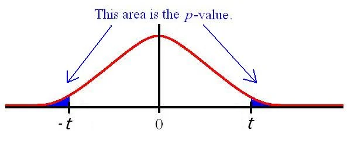

- img. above is pdf of t-distribution
- p-value = 2(area1) = 2(area2) = $2Pr(T>t)=Pr(T>|t|)$
- p value is the probability (between 0 and 1) that $H_0$ is true.
- a p-value that is < significance level (usually 0.05), the we reject $H_0$.
  - (accepting $H_1$)
  - example : P value of 0.00000000005 we can reject
- a p-value that is > significance level (usually 0.05), then we fail to reject $H_0$.
  - not deterministic result
  - note p-value is only the probability
  - if we accept $H_1$ then we say it is true, which is not the case
  - example : P value of 0.25 we fail to reject
- consider p-value as uncertainty

### Special Case (sigma squared is known)

- $\sigma^2$ is known (happens in some homework problems)
- “ideal case”
- $t=\frac{\hat{\beta}_1-\hat{\beta}_{10}}{se(\hat{\beta}_{10})\}}\sim N(0,1)$

### One sided Test

- A two sided test is what we were looking at before.
- Often Written : $H_0$ : $\beta_0=\beta_{10}$ vs. $H_1$ : $\beta_0\ne\beta_{10}$
- A one sided test is : $H_0$ : $\beta_0=\beta_{10}$ vs. $H_1$ : $\beta_0>\beta_{10}$
- if test is one sided, then it will depend which side the p-value is on
- only one side is being counted ($\frac{1}{2}$ Area)

### Summary

- will revisit t (and maybe prove in a different form)
- update code page
- create homework page?
- fill in holes in notes
- finish chapter 2
- peek at chapter 3

# W3-D8 : Wed. Oct. 13th, 2021

- this next section follows the book (something to do with $R^2$)

### Analysis of Variance

$\sum\limits_{i=1}^{n}(y_i-\overline{y})^2$

- SSTO = Sum Square Total
- when we calculate simple variance of $y_i$ we use this formula
- sometimes we might have a $\frac{1}{n}$ or some other constant in front of the sigma, but we can forget about that
- the data point ($y_i$) minus the center point ($\overline{y}$)
  - the distance between the point and data mean (visualize graphically)
- we will decompose this into two parts

$\sum\limits_{i=1}^{n}(y_i-\overline{y})^2=\sum\limits_{i=1}^{n}(y_i-\hat{y}_i)^2+\sum\limits_{i=1}^{n}(\hat{y}_i-\overline{y})^2$

- the first part is the residual : $\sum\limits_{i=1}^{n}(y_i-\hat{y}_i)^2$
  - SSE : Sum Square of Error
  - if our model perfectly fits the data then $\hat{y}$ will be $y_i$ and residual will be zero
  - $SS_{RE}$
- the second part is variability of fitted data (SSR): $\sum\limits_{i=1}^{2}(\hat{y}_i-\overline{y})^2$
  - $\overline{\hat{y}}=\overline{y}$ : average of estimated y is the same as the original value
  - SSR : Sum Square of Regression
  - $SS_{Reg}$
- everything is decomposing this : $\sum\limits_{i=1}^{n}(y_i-\overline{y})^2$ variance
  - this means that the variance of the data ($\sum\limits_{i=1}^{n}(y_i-\overline{y})^2$) can be explained by the variance of the error ($\sum\limits_{i=1}^{n}(y_i-\hat{y}_i)^2$) and the variance of model ($\sum\limits_{i=1}^{2}(\hat{y}_i-\overline{y})^2$)

### Proof : Analysis of Variance

  $\sum\limits_{i=1}^{n}(y_i-\overline{y})^2=\sum\limits_{i=1}^{n}(y_i-\hat{y}_i)^2+\sum\limits_{i=1}^{2}(\hat{y}_i-\overline{y})^2$ is true.

$$\begin{equation}\label{analysis of var. proof part a}
\begin{split}
\sum\limits_{i=1}^{n}(y_i-\overline{y})^2 & = \sum\limits_{i=1}^{n}(y_i-\hat{y}_i)^2+\sum\limits_{i=1}^{2}(\hat{y}_i-\overline{y})^2\\
& = \sum\limits_{i=1}^{n}(y_i-\hat{y}_i+\hat{y}_i-\overline{y})^2\\
& = \sum\limits_{i=1}^{n}\{(y_i-\hat{y}_i)^2+(\hat{y}_i-\overline{y})^2+2(y_i-\hat{y}_i)(\hat{y}_i-\overline{y})\}
\end{split}
\end{equation}$$

What we need to show is that this term : $(y_i-\hat{y}_i)(\hat{y}_i-\overline{y})$ , is zero.

- $\sum\limits_{i=1}^n(y_i-\hat{y}_i)(\hat{y}_i-\overline{y}) = 0$

$$\begin{equation}\label{aov lemma}
\begin{split}
\sum\limits_{i=1}^{n}(y_i-\hat{y}_i)(\hat{y}_i-\overline{y}) & = \sum\limits_{i=1}^n(y_i-\hat{y}_i)\hat{y}_i-\sum\limits_{i=1}^n(y_i-\hat{y}_i)\overline{y}\\
& = \sum\limits_{i=1}^ne_i\hat{y}_i-\overline{y}\sum\limits_{i=1}^ne_i\\
& = 0 - 0\\
& = 0
\end{split}
\end{equation}$$

- note to show that $\sum\limits_{i=1}^ne_i\hat{y}_i=0$ write out each of the individual terms for $\hat{y}_i$ and $e_i$

Therefore $\sum\limits_{i=1}^n(y_i-\hat{y}_i)(\hat{y}_i-\overline{y}) = 0$ , and such $\sum\limits_{i=1}^{n}(y_i-\overline{y})^2=\sum\limits_{i=1}^{n}(y_i-\hat{y}_i)^2+\sum\limits_{i=1}^{2}(\hat{y}_i-\overline{y})^2$

### Degrees of Freedom

- in probability theory we need to look at the degrees of freedom : df
  - for SSTO : df = n - 1
  - for SSE : df = n-2
    - $\hat{\beta}_0$ and $\hat{\beta}_1$
  - for SSR : df = 1

### Decomposing terms : SSE , SSR , MSE

$1=\frac{SSE+SSR}{SSTO}=\frac{SSE}{SSTO}+\frac{SSR}{SSTO}$

- SSTO is fixed
- $+\frac{SSR}{SSTO}$ is $R^2$ (we will talk more about $R^2$ when we talk about the confidence interval)
- $\frac{SSE}{SSTO}$ is
- we use SSE to estimate the variance
  - once we have variance we can show probability, density, or distribustion of almost anything

$SSE=\frac{n-2}{\sigma^2}\sim x^2_{n-2}$

- chi squared n - 2 distribution
- $\frac{SSE}{\sigma^2}=MSE\frac{n-2}{\sigma^2}$

$SSR=1\cdot MSR\sim x_1^2$

- chi squared 1 distribution
- $\frac{SSR}{\sigma^2}=1\cdot \frac{MSR}{\sigma^2}$

$E(MSE)=\sigma^2$

> $MSE=\frac{1}{n-2}\sum\limits_{i=1}^n(y_i-\hat{y}_i)^2$

$MSE=\frac{SSE}{n-2}$

$MSE=\frac{SSE}{\text{df of SSE}}$

$MSR=\frac{SSR}{\text{df of SSR}}$

### F and T Statistic

What happens when we take one and divide it by another one?

- put the smaller one (degrees of freedom) ontop of the larger one

$\sqrt{\frac{MSR}{MSE}}=\frac{1\cdot\frac{MSR}{\sigma^2}}{MSE\frac{n-2}{\sigma^2}}=\frac{MSR}{(???)MSE}=\frac{\chi_1^2/1}{\chi_{n-2}^2/n-2}$

F statistic : $F_{1, n-2}\sim \frac{\chi_1^2/1}{\chi_{n-2}^2/n-2}$

$\frac{\chi^2_m/m}{\chi_n/n}\sim F_{m,n}$ , if $\chi^2_n$ is (independent) from $\chi^2_m$ then

- $\newcommand{\indep}{\perp \!\!\! \perp}\chi^2_n\indep \chi^2_m$

We have another problem … what about T distribution?

$T\sim df_n$

What is $T^2$ distribution?

- $T^2\sim F_n$

We can change these : $T\sim df_{n-2}$ and $T^2\sim F_{n-2}$

### Key Points

- The analysis equations is the most critical result
- we also decompose this equation into many terms, with each term responding to error , regresseion with … a bunch of stuff.
- if we find that any term is too small to consider we can remove it (here is only two parts so not very complex)

Test : $\beta_1=0$ vs. $\beta_1\ne0$

### Confidence Interval of parameter

Pr($1,\beta_1<\mu=1-\alpha)=<\alpha\ne1$

- of course we want this probability to be 1
- currently we dont know if this is the number we have or not
- next we are going to try to connect bact to $1-\alpha$
- probability of random vairable : $\beta_1$ is computed here

$t=\frac{\hat{\beta}_1-\beta_1}{s.e.(\hat{\beta}_1)}\sim t_{n-2}$

- distribution of $\beta_1$ is defined here

Can we solve for our $\mu$?

- if we can we can find the interval for $\beta_1$
- we will do this this Friday.

### Summary

- analysis of variance : $\sum\limits_{i=1}^{n}(y_i-\overline{y})^2=\sum\limits_{i=1}^{n}(y_i-\hat{y}_i)^2+\sum\limits_{i=1}^{n}(\hat{y}_i-\overline{y})^2$
- SSTO : sum of squares total : $\sum\limits_{i=1}^{n}(y_i-\overline{y})^2$
- SSE : sum of square error : $\sum\limits_{i=1}^{n}(y_i-\hat{y}_i)^2$
- SSR : sum of square regression : $\sum\limits_{i=1}^{n}(\hat{y}_i-\overline{y})^2$
- MSE : mean square error (??) : $MSE=\frac{1}{n-2}\sum\limits_{i=1}^n(y_i-\hat{y}_i)^2$
- F Statistic : $\frac{\chi^2_m/m}{\chi_n/n}\sim F_{m,n}$
- T Statistic : $T^2\sim F_{n-2}$
- Confidence interval for $\beta_1$’s
  - probaility : Pr($1,\beta_1<\mu=1-\alpha)=<\alpha\ne1$
  - distribution : $t=\frac{\hat{\beta}_1-\beta_1}{s.e.(\hat{\beta}_1)}\sim t_{n-2}$
- HW 2 is live : Proofs and fill in skipped questions from HW 1

# W3-D9 : Fri. Oct. 15th, 2021

- Problem is that we want to find the confidence interval (CI) for parameters $\beta_0$ and $\beta_1$, and $\sigma^2$

### CI For Beta_0 , Beta_1, and Sigma Squared

$Pr\{l<\beta_1<u\}=1-\alpha$

- we want probability that $\beta_1$ is greater than some lower bound and less than some upper bound is equal to some number, lets call alpha for now
- currently we don’t know the lower and the upper
  - we do know $t=\frac{\hat{\beta}_1-\beta_1}{s.e.(\hat{\beta}_1)}\sim t_{n-2}$
  - which is a different form of $\beta_1$
  - call this ratio t
- we also don’t know the distribution of $\beta_1$. If we did we knew that we would know the probability and be able to find the lower and upper bounds.

$$\begin{equation}\label{pr beta 1}
\begin{split}
1-\alpha & = Pr\{l<\beta_1<u\}\\
& = Pr\{-u<-\beta_1<-l\}\\
& = Pr\{\hat{\beta}_1-u<\hat{\beta}_1-\beta_1<\hat{\beta}_1-l\}\\
& = Pr\{\frac{\hat{\beta}_1-u}{s.e.(\hat{\beta}_1)}<\frac{\hat{\beta}_1-\beta_1}{s.e.(\hat{\beta}_1)}<\frac{\hat{\beta}_1-l}{s.e.(\hat{\beta}_1)}\}
\end{split}
\end{equation}$$

- now the probabilty becomes :

$Pr(\frac{\hat{\beta}_1-u}{s.e.(\hat{\beta}_1)}<t<\frac{\hat{\beta}_1-l}{s.e.(\hat{\beta}_1)})=1-\alpha$

- we know t-distribution, so if we can figure our $\hat{\beta}_1$ and $s.e.(\hat{\beta}_1)$ then we can find upper and lower bounds

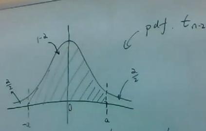

- we have and even distribution with evenly distanced intevals a and -a
- we know the area between these two points is $1-\alpha$
- that means the area of ends is $\frac{\alpha}{2}$
- $a=t_{\frac{\alpha}{2},n-2}$ , $t_{1-\frac{\alpha}{2},n-2}$ , $t_{n-2}^{\frac{\alpha}{2}}$
- plug in $a=t_{\frac{\alpha}{2},n-2}$ , then we have

$\frac{\hat{\beta}_1-u}{s.e.(\hat{\beta}_1)}=-t_{\frac{\alpha}{2},n-2}$

$\Rightarrow u=\hat{\beta}_1+t_{\frac{\alpha}{2},n-2}\cdot s.e.(\hat{\beta}_1)$

$\Rightarrow l=\hat{\beta}_1-t_{\frac{\alpha}{2},n-2}\cdot s.e.(\hat{\beta}_1)$

- put this back in the original equation : $Pr\{l<\beta_1<u\}=1-\alpha$
- If we want a 99% confidence interval then our alpha needs to be 1%
- 95% CI, $\alpha=0.05$

For $Pr\{l<\beta_0<u\}=1-\alpha$ the CI are :

$\Rightarrow u=\hat{\beta}_0+t_{\frac{\alpha}{2},n-2}\cdot s.e.(\hat{\beta}_0)$

$\Rightarrow l=\hat{\beta}_0-t_{\frac{\alpha}{2},n-2}\cdot s.e.(\hat{\beta}_0)$

### CI of Sigma Squared

$\sigma^2$ ?

$Pr\{l<\sigma^2<u\}=1-\alpha$

$\frac{(n-2)MSE}{\sigma^2}\sim \chi^2_{n-2}$

- this ratio is chi squared distribution with degrees of freedom n-2. wont prove but will need to know decompositions to prove

To help remember :

$E(SSE)=(n-2)\sigma^2$

$MSE=\frac{1}{n-2}SSE$

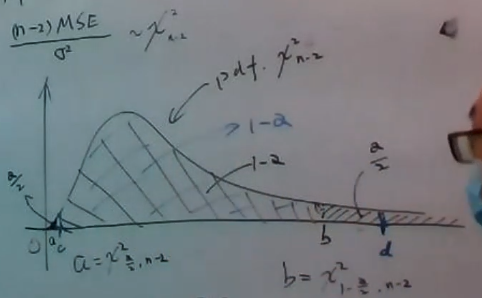

- we are still looking for some interval c and d such that the blue area is $1-\alpha$.
- area of a and b are : $a=\chi^2_{\frac{\alpha}{2},n-2}$ and $b=\chi^2_{1-\frac{\alpha}{2},n-2}$

$Pr\{\frac{(n-2)MSE}{u}<\frac{(n-2)MSE}{\sigma^2}<\frac{(n-2)MSE}{l}\}=1-\alpha$

- the lower probability is a and the upper probability is b so,

$\Rightarrow u=\frac{(n-2)MSE}{\chi^2_{\frac{\alpha}{2},n-2}}$

$\Rightarrow l=\frac{(n-2)MSE}{\chi^2_{1-\frac{\alpha}{2},n-2}}$

- in this course we do not care too much for the CI of $\sigma^2$, but about the CI for $\beta_1$ and $\beta_0$

### Prediction

- what people really want is the response, the prediction

model : $Y=\beta_0+\beta_1x+\epsilon$

- $\beta_0+\beta_1x$ : first part is what we can determine (linear part).
- $\epsilon$ : second part is something random, not in our control.
  - assume normal

description : $\{x_i,y_i\}^n_{i=1}$

- $y_i=\hat{\beta}_0+\hat{\beta}_1x_i$

estimated model : $\hat{y}_i=\hat{\beta}_0+\hat{\beta}_1x$

point prediction : $y_{\text{new}}=\hat{\beta}_0+\hat{\beta}_1x_{\text{new}}+\epsilon_{\text{new}}$

- dont know random unknown term $\epsilon_{\text{new}}$

We can comput the CI of $\hat{\beta}_0$ and $\hat{\beta}_1$

- key part of this is that the $Var(\hat{\beta}_0)$ and $Var(\hat{\beta}_1)$

Now want the CI of $y_{\text{new}}$

- we already know $\hat{y}_{\text{new}}=???$ this is our hat estimate
- next step is $Var(y_{\text{new}})$
  - if we can compute the variance of y hat then we can compute our CI

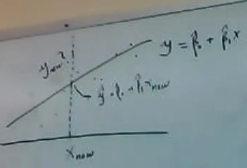

- this is a straight line
- given $x_{\text{new}}$ we can find our prediction on this straight line

So what is $y_{\text{new}}$

- it should be somewhere along the blue line
- so we will find an interval that 95% of the data lies within, that we can way with 95% confidence that $y_{\text{new}}$ lies within
- $Var(y_{\text{new}})$ is so important because it will help us with calculations from earlier in lecture (for upper and lower values : u and l)

$$\begin{equation}\label{var of y hat}
\begin{split}
Var\{y_{\text{new}}\} & = Var\{\hat{\beta}_0+\hat{\beta}_1x_{\text{new}}+\epsilon_{\text{new}}\}\\
& = Var\{\hat{\beta}_0+\hat{\beta}_1x_{\text{new}}\}+Var\{\epsilon_{\text{new}}\}\\
& = Var\{\hat{y}\}+\sigma^2
\end{split}
\end{equation}$$

What you need to do next is write out the formular for $\hat{y}$ and take the square root : $\sqrt{...\cdot\sigma^2}$

- will expand on the details on Monday
- Homework expanded to Wednesday so we can do all predictions and confidence interval

### Summary

- will expand on prediction on monday

For $Pr\{l<\beta_1<u\}=1-\alpha$ the CI are :

$\Rightarrow u=\hat{\beta}_1+t_{\frac{\alpha}{2},n-2}\cdot s.e.(\hat{\beta}_1)$

$\Rightarrow l=\hat{\beta}_1-t_{\frac{\alpha}{2},n-2}\cdot s.e.(\hat{\beta}_1)$

For $Pr\{l<\beta_0<u\}=1-\alpha$ the CI are :

$\Rightarrow u=\hat{\beta}_0+t_{\frac{\alpha}{2},n-2}\cdot s.e.(\hat{\beta}_0)$

$\Rightarrow l=\frac{(n-2)MSE}{\chi^2_{1-\frac{\alpha}{2},n-2}}$

### To Do

- prep homework 2 (complete)